# Coursera Practical Machine Learning Course Project

Simon Wongsuwarn

22 March 2016

```r
library(gridExtra)
library(caret)
library(plyr)
library(dplyr)
library(C50)
library(randomForest)
library(survival)
```

I begin by reading the training and final testing data:

```r
dat <- read.csv("~/Downloads/pml-training.csv",
                row.names = 'X', stringsAsFactors=FALSE)
final_testing <- read.csv("~/Downloads/pml-testing.csv",
                    row.names = 'X', stringsAsFactors=FALSE)
```

As suggested in a [flowingdata.com post](https://flowingdata.com/2015/02/18/loading-data-and-basic-formatting-in-r/) I set the parameter `stringsAsFactors` to `FALSE`.

I explore the dataset:

```r
head(dat)
str(dat$classe)
```

The response variable should be a factor variable:

```r
dat$classe <- as.factor(dat$classe)
```

Many numeric feature vectors have also been read as character vectors so I correct that with the help of a [stackoverflow_post](http://stackoverflow.com/questions/27528907/how-to-convert-data-frame-column-from-factor-to-numeric):

```r
indx <- sapply(dat, is.character)
dat[indx] <- lapply(dat[indx], function(x) as.numeric(x))
```

I check a response variable historgram to spot any rarely occurring outcomes that would potentially be problematic and there are none:

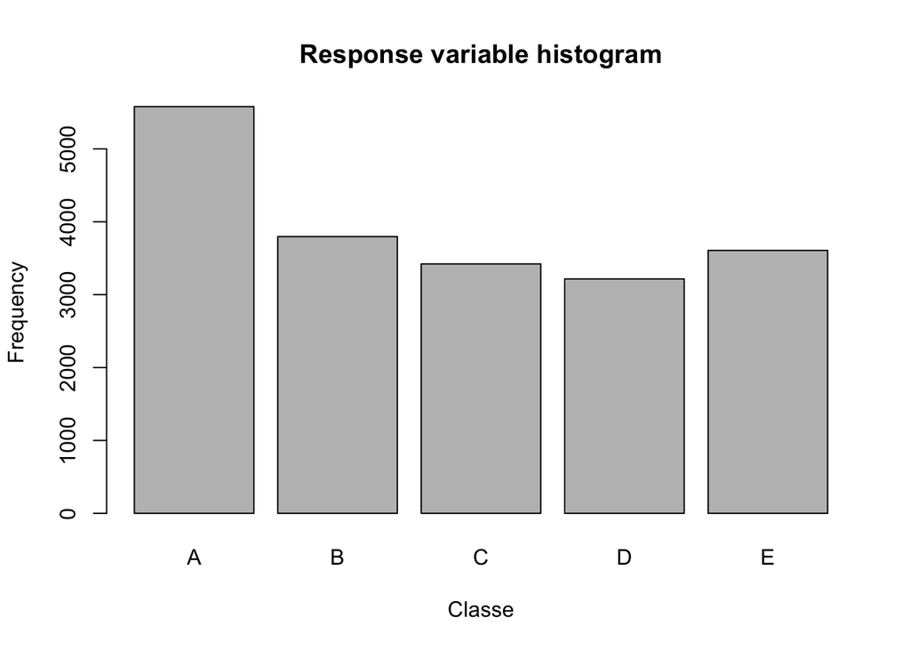

```r
plot(dat$classe,xlab="Classe", ylab="Frequency",main="Response variable histogram")
```

I create a subset that removes six variables from the data that I do not want to use as features. The `user_name` variable is removed as I don’t want the model to rely on any particular user performing the exercise. I also don’t want the model to rely on the exercise being performed at any particular time or relative time interval (say, if the user’s performed the exercises in sequence) so the timestamp features are removed. Finally, the `num_window` and `new_window` features are removed as they appear to correspond to the recording software and not the exercise itself:

```r
dat_subset <- subset(dat,select =
                      -c(user_name,
                         raw_timestamp_part_1,
                         raw_timestamp_part_2,
                         cvtd_timestamp, num_window, new_window))
```

The dataset is many times larger than the `Wage` dataset (`ISLR` library) used in the course. I therefore believe that the current Weight Lifting exercises dataset constitutes a “large sample size”" and follow the sample division guidelines as per the course:

```r
inBuild <- createDataPartition(y=dat_subset$classe,p=0.8,list=FALSE)
validation <- dat_subset[-inBuild,] # 20% of data for validation
buildData <- dat_subset[inBuild,]
inTrain <- createDataPartition(y=buildData$classe,p=6/8,list=FALSE)
training = buildData[inTrain,] # 60% of data for training
testing = buildData[-inTrain,] # 20% of data for testing
```

I create subsets for the training, testing and validation samples where variables with near zero variability are thrown out:

```r
nzvCheck <- nearZeroVar(training, saveMetrics=TRUE)
nzvCheck$feature <- row.names(nzvCheck)
fzvFeatures <- nzvCheck %>% filter(nzv==FALSE) %>% select(feature)

training_nzvRemoved <- subset(training,select=fzvFeatures[,1])
testing_nzvRemoved <- subset(testing,select=fzvFeatures[,1])
validation_nzvRemoved <- subset(validation,select=fzvFeatures[,1])
```

I visualise the first eight features with density plots:

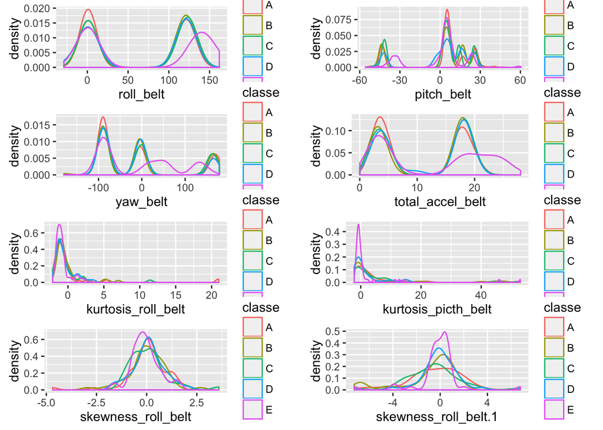

I see many non-Gaussian feature distributions. Further, many features have zero and/or negative values. For these reasons we cannot perform a simple transformation e.g. `BoxCox`. Instead, it is better to pursue scale-invariant methods such as random forest or stochastic gradient boosting.

I use `medianImpute` to impute missing data:

```r
preObj <- preProcess(subset(training_nzvRemoved,select=-classe),method="medianImpute")
training_impd <- predict(preObj,subset(training_nzvRemoved,select=-classe))

postObj <- preProcess(subset(testing_nzvRemoved,select=-classe),method="medianImpute")
testing_impd <- predict(postObj,subset(testing_nzvRemoved,select=-classe))

valObj <- preProcess(subset(validation_nzvRemoved,select=-classe),method="medianImpute")
validation_impd <- predict(valObj,subset(validation_nzvRemoved,select=-classe))
```

The three models constructed and tuned are Random Forests (RF), Stochastic Gradient Boosting (GBM), and Boosted C5.0 (C50). Cross-validation (CV) is a type of resampling method which involves repeatedly splitting the sample training data into an in-sample training set and an in-sample testing set, and using each repeat to assess the model. `k-fold CV` refers to a type of CV where the sample training data is randomly split into `k` groups of approximately equal size. Each group is used once as the in-sample testing set.

Here, each model is automatically tuned and is evaluated using 5-fold cross validation using the `trainControl` method found in the `caret` package:

```r
## 5-fold CV
fitControl <- trainControl(method = "cv", number = 5)
```

**Note**: *My machine has a 1.3 GHz Intel Core M processor which means that processing time is a problem. For this reason I only used 5-fold CV instead of 10-fold and I didn’t use repeats during training. I would have otherwise introduced the `repeats` parameter into the `trainControl` function as well.*

I also set the random number seed before each training to ensure that the same data partitions (this would also have ensured the same repeats, had I run with repeats on a machine with a faster processor). I pass the `Kappa` argument to the metric parameter as my response factors are not balanced (histogram above):

```r
# train the RF model
# limit mtry = 63 to save processing time as I'd previously run a full grid
# and a value of 63 was optimum)
mtryGrid <- expand.grid(mtry = 63)
set.seed(7)
rfFit<- train(training$classe ~ ., data = training_impd, method = "rf",
              do.trace=FALSE, trControl = fitControl, metric = "Kappa",
              tuneGrid = mtryGrid)

# train the GBM model
set.seed(7)
gbmFit <- train(training$classe ~ ., data = training_impd, method = "gbm",
                 metric = "Kappa", trControl = fitControl, verbose = FALSE)

# train the C50 model
set.seed(7)
c50Fit <- train(training_nzvRemoved$classe ~ ., data = training_impd,
                trControl=fitControl, method="C5.0", verbose=FALSE,
                metric = "Kappa")
```

Now we can compare the `Kappa` distributions between the models (each model has 5 results following 5-fold cross validation):

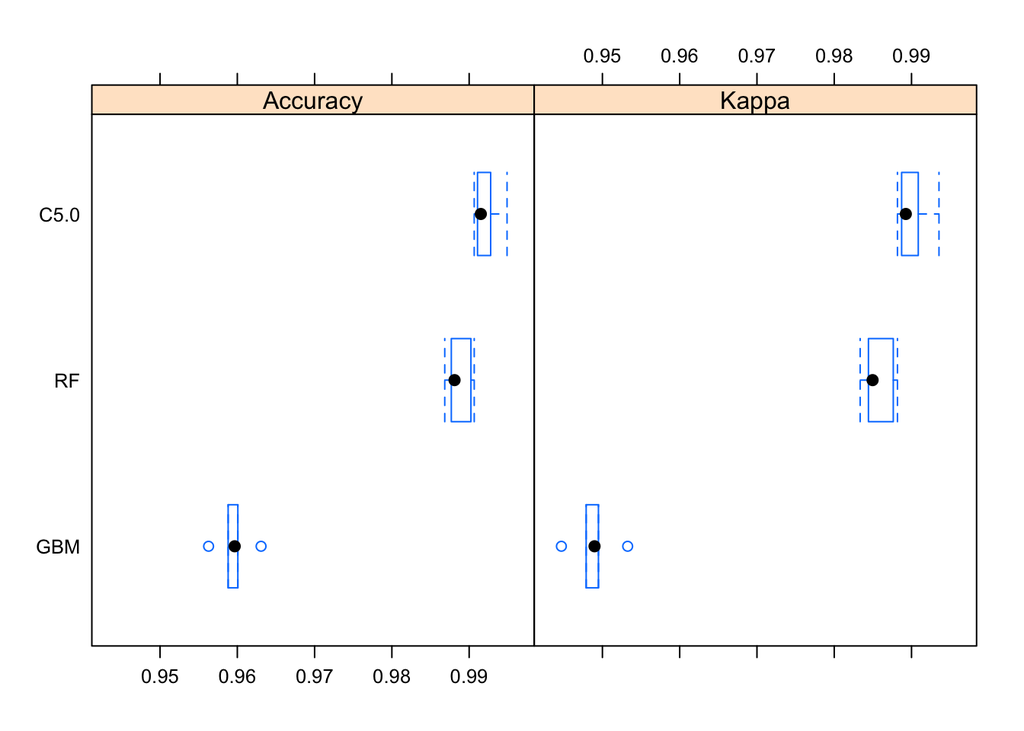

```r
cvValues <- resamples(list(GBM = gbmFit, RF = rfFit, C5.0 = c50Fit))
bwplot(cvValues)
```

We see that the Boosted C5.0 and Random Forest models are comparable, and both appear to have performed better than the Stochastic Gradient Boosting model.

Let’s see how they perform on the test data:

```r
confusionMatrix(testing$classe,predict(rfFit,testing_impd))
```

```
## Confusion Matrix and Statistics
##
##           Reference
## Prediction    A    B    C    D    E
##          A 1115    0    0    0    1
##          B   11  744    4    0    0
##          C    0    2  681    1    0
##          D    0    1    9  631    2
##          E    0    1    1    0  719
##
## Overall Statistics
##
##                Accuracy : 0.9916
##                  95% CI : (0.9882, 0.9942)
##     No Information Rate : 0.287
##     P-Value [Acc > NIR] : < 2.2e-16
##
##                   Kappa : 0.9894
##  Mcnemar's Test P-Value : NA
##
## Statistics by Class:
##
##                      Class: A Class: B Class: C Class: D Class: E
## Sensitivity            0.9902   0.9947   0.9799   0.9984   0.9958
## Specificity            0.9996   0.9953   0.9991   0.9964   0.9994
## Pos Pred Value         0.9991   0.9802   0.9956   0.9813   0.9972
## Neg Pred Value         0.9961   0.9987   0.9957   0.9997   0.9991
## Prevalence             0.2870   0.1907   0.1772   0.1611   0.1840
## Detection Rate         0.2842   0.1897   0.1736   0.1608   0.1833
## Detection Prevalence   0.2845   0.1935   0.1744   0.1639   0.1838
## Balanced Accuracy      0.9949   0.9950   0.9895   0.9974   0.9976
```

```r
# # RF model out of sample Kappa: 0.99
confusionMatrix(testing$classe,predict(gbmFit,testing_impd))
```

```
## Confusion Matrix and Statistics
##
##           Reference
## Prediction    A    B    C    D    E
##          A 1098   10    7    0    1
##          B   22  716   20    0    1
##          C    0   19  660    5    0
##          D    0    4   21  612    6
##          E    1    6   10    6  698
##
## Overall Statistics
##
##                Accuracy : 0.9646
##                  95% CI : (0.9583, 0.9701)
##     No Information Rate : 0.2858
##     P-Value [Acc > NIR] : < 2.2e-16
##
##                   Kappa : 0.9552
##  Mcnemar's Test P-Value : NA
##
## Statistics by Class:
##
##                      Class: A Class: B Class: C Class: D Class: E
## Sensitivity            0.9795   0.9483   0.9192   0.9823   0.9887
## Specificity            0.9936   0.9864   0.9925   0.9906   0.9929
## Pos Pred Value         0.9839   0.9433   0.9649   0.9518   0.9681
## Neg Pred Value         0.9918   0.9877   0.9821   0.9966   0.9975
## Prevalence             0.2858   0.1925   0.1830   0.1588   0.1800
## Detection Rate         0.2799   0.1825   0.1682   0.1560   0.1779
## Detection Prevalence   0.2845   0.1935   0.1744   0.1639   0.1838
## Balanced Accuracy      0.9865   0.9674   0.9559   0.9865   0.9908
```

```r
# # GBM model out of sample Kappa: 0.96
confusionMatrix(testing$classe,predict(c50Fit,testing_impd))
```

```
## Confusion Matrix and Statistics
##
##           Reference
## Prediction    A    B    C    D    E
##          A 1115    0    0    0    1
##          B    8  745    5    0    1
##          C    0    4  680    0    0
##          D    0    1    6  635    1
##          E    0    0    0    0  721
##
## Overall Statistics
##
##                Accuracy : 0.9931
##                  95% CI : (0.99, 0.9955)
##     No Information Rate : 0.2863
##     P-Value [Acc > NIR] : < 2.2e-16
##
##                   Kappa : 0.9913
##  Mcnemar's Test P-Value : NA
##
## Statistics by Class:
##
##                      Class: A Class: B Class: C Class: D Class: E
## Sensitivity            0.9929   0.9933   0.9841   1.0000   0.9959
## Specificity            0.9996   0.9956   0.9988   0.9976   1.0000
## Pos Pred Value         0.9991   0.9816   0.9942   0.9876   1.0000
## Neg Pred Value         0.9971   0.9984   0.9966   1.0000   0.9991
## Prevalence             0.2863   0.1912   0.1761   0.1619   0.1846
## Detection Rate         0.2842   0.1899   0.1733   0.1619   0.1838
## Detection Prevalence   0.2845   0.1935   0.1744   0.1639   0.1838
## Balanced Accuracy      0.9963   0.9945   0.9914   0.9988   0.9979
```

```r
# C5.0 model out of sample Kappa: 0.99
```

The same relative conclusions between models can be drawn from the out of sample error as previously concluded from the in sample error. Further, the absolute values of Accuracy and Kappa are very similar suggesting that the model has not overfitted the training data.

```r
confusionMatrix(testing$classe,predict(c50Fit,validation_impd))
```

```
## Confusion Matrix and Statistics
##
##           Reference
## Prediction    A    B    C    D    E
##          A 1114    2    0    0    0
##          B   13  740    5    0    1
##          C    0    1  678    5    0
##          D    0    1    6  635    1
##          E    0    0    0    3  718
##
## Overall Statistics
##
##                Accuracy : 0.9903
##                  95% CI : (0.9867, 0.9931)
##     No Information Rate : 0.2873
##     P-Value [Acc > NIR] : < 2.2e-16
##
##                   Kappa : 0.9877
##  Mcnemar's Test P-Value : NA
##
## Statistics by Class:
##
##                      Class: A Class: B Class: C Class: D Class: E
## Sensitivity            0.9885   0.9946   0.9840   0.9876   0.9972
## Specificity            0.9993   0.9940   0.9981   0.9976   0.9991
## Pos Pred Value         0.9982   0.9750   0.9912   0.9876   0.9958
## Neg Pred Value         0.9954   0.9987   0.9966   0.9976   0.9994
## Prevalence             0.2873   0.1897   0.1756   0.1639   0.1835
## Detection Rate         0.2840   0.1886   0.1728   0.1619   0.1830
## Detection Prevalence   0.2845   0.1935   0.1744   0.1639   0.1838
## Balanced Accuracy      0.9939   0.9943   0.9911   0.9926   0.9981
```

```r
# C5.0 model out of sample Kappa: 0.99
```

The expected out of sample Kappa is 0.99.

In order to complete the project quiz, I use the best performing algorithm to predict the classes on the [20 test cases dataset](https://d396qusza40orc.cloudfront.net/predmachlearn/pml-testing.csv).

```r
final_testing_subset <- subset(final_testing,select = -c(user_name,
                         raw_timestamp_part_1, raw_timestamp_part_2,
                         cvtd_timestamp, num_window, new_window))

# do not select problem_id feature
final_testing_nzvRemoved <- subset(final_testing_subset,select=filter(fzvFeatures,feature!="classe")$feature)
pp <- preProcess(final_testing_nzvRemoved,method="medianImpute")
final_testing_nzvRemoved_impd <- predict(preObj,final_testing_nzvRemoved)
predict(c50Fit,newdata=final_testing_nzvRemoved_impd)
```

```
##  [1] B A B A A E D B A A B C B A E E A B B B
## Levels: A B C D E
```

The data for this project came from this [source](http://groupware.les.inf.puc-rio.br/har).